# MEFAdapt mining data

MEFAdapt project

2024

# A short walktrough the data

The S&P mining data contains information on 40702 mines globally. It contains information on location of these mines, the type of mineral that is explored, and the type of technology used for mining and processing. However, not all mines have complete information on all variables.

## Commodities

This is the list of commodities that are explored in the dataset. ‘n’ is the number of mines that explore each commodity, and ‘perc’ is the percentage of mines that explore each commodity. It is possible to see here that around 35 and 13% of the mines explore gold and copper, respectively.

|  | PRIMARY_COMMODITY | n | perc |
| --- | --- | --- | --- |
| 1 | Gold | 14327 | 35.2 |
| 2 | Coal | 5360 | 13.2 |
| 3 | Copper | 5351 | 13.1 |
| 4 | Iron Ore | 2185 | 5.4 |
| 5 | U3O8 | 1736 | 4.3 |
| 6 | Nickel | 1597 | 3.9 |
| 7 | Zinc | 1449 | 3.6 |
| 8 | Diamonds | 1445 | 3.6 |
| 9 | Lead | 1262 | 3.1 |
| 10 | Silver | 1191 | 2.9 |

[output cut: 36 more lines]

However, some mines have more than one commodity. The table below shows the relationship between the ‘primary commodity’ and the other commodities explored in the same mine. The table is sorted by the number of mines that explore each combination of commodities.

|  | PRIMARY_COMMODITY | COMMODITIES_LIST | n | perc |
| --- | --- | --- | --- | --- |
| 1 | Gold | Gold | 8643 | 21.235 |
| 2 | Coal | Coal | 5355 | 13.157 |
| 3 | Gold | Gold,Silver | 2076 | 5.1 |
| 4 | Iron Ore | Iron Ore | 1729 | 4.248 |
| 5 | Diamonds | Diamonds | 1393 | 3.422 |
| 6 | U3O8 | U3O8 | 1362 | 3.346 |
| 7 | Copper | Copper | 1189 | 2.921 |
| 8 | Copper | Copper,Gold | 873 | 2.145 |
| 9 | Lead | Lead | 862 | 2.118 |
| 10 | Gold | Gold,Copper | 585 | 1.437 |

[output cut: 4132 more lines]

## Production Methods

The table below shows types of technology used in mining according to the dataset. As seen here, unfortunately for more than 80% of the mines, this information is not available.

|  | MINING_METHODS | n | perc |
| --- | --- | --- | --- |
| 1 | Unknown | 32887 | 80.799 |
| 2 | Open Pit | 3312 | 8.137 |
| 3 | Underground | 1759 | 4.322 |
| 4 | Open Pit, Underground | 624 | 1.533 |
| 5 | Long Wall | 121 | 0.297 |
| 6 | Placer | 108 | 0.265 |
| 7 | Brine | 100 | 0.246 |
| 8 | Tailings | 80 | 0.197 |
| 9 | In-Situ Leach | 79 | 0.194 |
| 10 | Long Hole Stoping, Open Pit | 60 | 0.147 |

[output cut: 413 more lines]

The same is true for the data on processing methods, and production forms.

|  | PROCESSING_METHODS | PRODUCTION_FORMS | n | perc |
| --- | --- | --- | --- | --- |
| 1 | Unknown | Unknown | 33752 | 82.925 |
| 2 | Washing | Unknown | 491 | 1.206 |
| 3 | Crushing | Unknown | 379 | 0.931 |
| 4 | Unknown | Concentrate | 263 | 0.646 |
| 5 | Crushing, Flotation, Grinding | Concentrate | 251 | 0.617 |
| 6 | Flotation | Concentrate | 208 | 0.511 |
| 7 | Smelting | Unknown | 140 | 0.344 |
| 8 | Heap Leach | Unknown | 139 | 0.342 |
| 9 | Flotation | Unknown | 85 | 0.209 |
| 10 | Ball, Crushing, Flotation, Semi-Autogenous Grinding | Concentrate | 68 | 0.167 |

[output cut: 2709 more lines]

## Operation Status

More than 54% of the mines in the dataset are inactive, for one reason or another.

|  | ACTV_STATUS | n | perc |
| --- | --- | --- | --- |
| 1 | Inactive | 22144 | 54.405 |
| 2 | Active | 15492 | 38.062 |
| 3 | Unknown | 1857 | 4.562 |
| 4 | Care And Maintenance | 489 | 1.201 |
| 5 | Temporarily On Hold | 422 | 1.037 |
| 6 | On Hold Awaiting Higher Prices | 101 | 0.248 |
| 7 | Rehabilitation | 87 | 0.214 |
| 8 | Under Litigation | 66 | 0.162 |
| 9 | On Hold Awaiting Financing | 44 | 0.108 |

These are the types of ‘development stages’ included in the dataset.

|  | DEV_STAGE | n | perc |
| --- | --- | --- | --- |
| 1 | Operating | 8029 | 19.726 |
| 2 | Exploration | 7366 | 18.097 |
| 3 | Target Outline | 6616 | 16.255 |
| 4 | Grassroots | 4944 | 12.147 |
| 5 | Reserves Development | 4143 | 10.179 |
| 6 | Closed | 2199 | 5.403 |
| 7 | Unknown | 1736 | 4.265 |
| 8 | Prefeas/Scoping | 1144 | 2.811 |
| 9 | Advanced Exploration | 1096 | 2.693 |
| 10 | Satellite | 703 | 1.727 |

[output cut: 10 more lines]

And finally, this is the full table with the combinations between ‘development stage’ and ‘operation status’.

|  | DEV_STAGE | ACTV_STATUS | n | perc |
| --- | --- | --- | --- | --- |
| 1 | Exploration | Inactive | 5726 | 14.068 |
| 2 | Operating | Active | 5065 | 12.444 |
| 3 | Grassroots | Inactive | 4604 | 11.311 |
| 4 | Target Outline | Active | 3419 | 8.4 |
| 5 | Target Outline | Inactive | 3131 | 7.692 |
| 6 | Reserves Development | Inactive | 2223 | 5.462 |
| 7 | Closed | Inactive | 2079 | 5.108 |
| 8 | Reserves Development | Active | 1774 | 4.359 |
| 9 | Exploration | Active | 1577 | 3.875 |
| 10 | Unknown | Inactive | 1506 | 3.7 |

[output cut: 134 more lines]

# A focus on energy transition minerals

This part of the analysis of the dataset focuses on minerals that are important for the energy transition.

These minerals are: Lithium, Cobalt, Nickel, Graphite, Rare Earth Elements, Copper, and Manganese.

First, we filter the dataset to include mines that explore these minerals more broadly, and then filter to show the mines in which these minerals are the primary commodity.

There are 40702 mines in the dataset. Of these, 13075 explore at least one of the energy transition minerals, and 8330 have one of these minerals as the primary commodity.

The table below show how many mines explore these minerals as their primary commodity.

|  | PRIMARY_COMMODITY | n |
| --- | --- | --- |
| 1 | Copper | 5351 |
| 2 | Nickel | 1597 |
| 3 | Lithium | 676 |
| 4 | Graphite | 330 |
| 5 | Manganese | 226 |
| 6 | Cobalt | 150 |

The table below show the number of mines in which these minerals are obtained as both a primary or non-primary commodity.

|  | PRIMARY_COMMODITY | n | sum |
| --- | --- | --- | --- |
| 1 | Copper | 5351 | 13075 |
| 2 | Gold | 2825 | 13075 |
| 3 | Nickel | 1597 | 13075 |
| 4 | Lithium | 676 | 13075 |
| 5 | Zinc | 552 | 13075 |
| 6 | Silver | 419 | 13075 |
| 7 | Graphite | 330 | 13075 |
| 8 | Manganese | 226 | 13075 |
| 9 | Iron Ore | 168 | 13075 |
| 10 | Platinum | 168 | 13075 |

[output cut: 27 more lines]

## Operation Status of Energy Transition Mines

Here we only considered the mines in which the energy transition minerals are explored as the primary commodity.

### Activity status and development stage for each energy transition mineral

|  | ACTV_STATUS | DEV_STAGE | PRIMARY_COMMODITY | n |
| --- | --- | --- | --- | --- |
| 1 | Active | Target Outline | Lithium | 244 |
| 2 | Active | Exploration | Lithium | 83 |
| 3 | Inactive | Exploration | Lithium | 56 |
| 4 | Active | Reserves Development | Lithium | 40 |
| 5 | Active | Prefeas/Scoping | Lithium | 39 |
| 6 | Inactive | Grassroots | Lithium | 37 |
| 7 | Active | Operating | Lithium | 32 |
| 8 | Inactive | Target Outline | Lithium | 23 |
| 9 | Active | Construction Started | Lithium | 19 |
| 10 | Active | Feasibility Complete | Lithium | 14 |

[output cut: 25 more lines]

|  | ACTV_STATUS | DEV_STAGE | PRIMARY_COMMODITY | n |
| --- | --- | --- | --- | --- |
| 1 | Active | Target Outline | Cobalt | 39 |
| 2 | Active | Exploration | Cobalt | 22 |
| 3 | Inactive | Target Outline | Cobalt | 20 |
| 4 | Inactive | Exploration | Cobalt | 16 |
| 5 | Active | Operating | Cobalt | 10 |
| 6 | Inactive | Reserves Development | Cobalt | 8 |
| 7 | Active | Reserves Development | Cobalt | 6 |
| 8 | Active | Prefeas/Scoping | Cobalt | 5 |
| 9 | Unknown | Operating | Cobalt | 3 |
| 10 | Active | Commissioning | Cobalt | 2 |

[output cut: 15 more lines]

|  | ACTV_STATUS | DEV_STAGE | PRIMARY_COMMODITY | n |
| --- | --- | --- | --- | --- |
| 1 | Active | Target Outline | Nickel | 203 |
| 2 | Inactive | Exploration | Nickel | 203 |
| 3 | Active | Operating | Nickel | 200 |
| 4 | Inactive | Grassroots | Nickel | 151 |
| 5 | Inactive | Target Outline | Nickel | 117 |
| 6 | Inactive | Reserves Development | Nickel | 90 |
| 7 | Active | Reserves Development | Nickel | 84 |
| 8 | Inactive | Closed | Nickel | 77 |
| 9 | Active | Exploration | Nickel | 50 |
| 10 | Active | Prefeas/Scoping | Nickel | 36 |

[output cut: 55 more lines]

|  | ACTV_STATUS | DEV_STAGE | PRIMARY_COMMODITY | n |
| --- | --- | --- | --- | --- |
| 1 | Inactive | Grassroots | Graphite | 98 |
| 2 | Inactive | Exploration | Graphite | 38 |
| 3 | Active | Exploration | Graphite | 24 |
| 4 | Active | Prefeas/Scoping | Graphite | 20 |
| 5 | Active | Grassroots | Graphite | 16 |
| 6 | Active | Operating | Graphite | 16 |
| 7 | Active | Reserves Development | Graphite | 16 |
| 8 | Active | Target Outline | Graphite | 15 |
| 9 | Inactive | Advanced Exploration | Graphite | 14 |
| 10 | Active | Feasibility Complete | Graphite | 10 |

[output cut: 18 more lines]

|  | ACTV_STATUS | DEV_STAGE | PRIMARY_COMMODITY | n |
| --- | --- | --- | --- | --- |
| 1 | Inactive | Exploration | Copper | 791 |
| 2 | Inactive | Grassroots | Copper | 714 |
| 3 | Active | Target Outline | Copper | 608 |
| 4 | Active | Operating | Copper | 581 |
| 5 | Inactive | Target Outline | Copper | 479 |
| 6 | Inactive | Reserves Development | Copper | 336 |
| 7 | Active | Exploration | Copper | 252 |
| 8 | Active | Reserves Development | Copper | 237 |
| 9 | Inactive | Closed | Copper | 213 |
| 10 | Unknown | Operating | Copper | 132 |

[output cut: 74 more lines]

|  | ACTV_STATUS | DEV_STAGE | PRIMARY_COMMODITY | n |
| --- | --- | --- | --- | --- |
| 1 | Inactive | Grassroots | Manganese | 40 |
| 2 | Active | Operating | Manganese | 33 |
| 3 | Inactive | Exploration | Manganese | 28 |
| 4 | Unknown | Operating | Manganese | 21 |
| 5 | Inactive | Unknown | Manganese | 12 |
| 6 | Inactive | Operating | Manganese | 11 |
| 7 | Active | Expansion | Manganese | 7 |
| 8 | Inactive | Closed | Manganese | 7 |
| 9 | Active | Construction Started | Manganese | 5 |
| 10 | Active | Prefeas/Scoping | Manganese | 5 |

[output cut: 31 more lines]

# Simplifying things

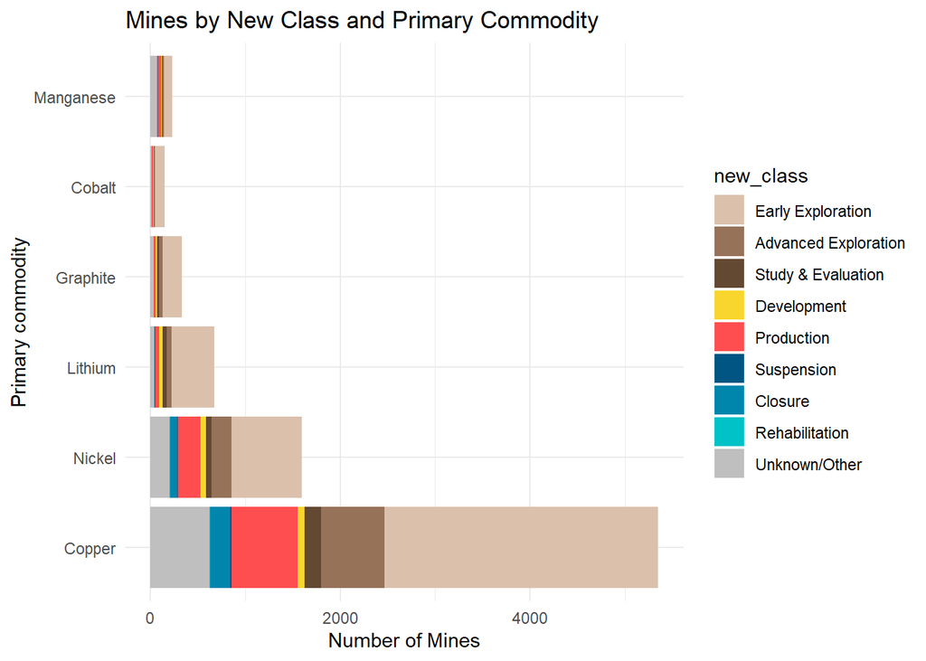

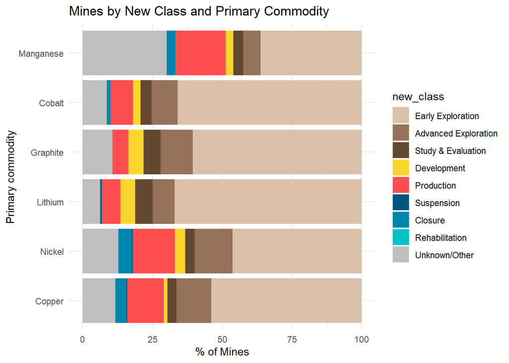

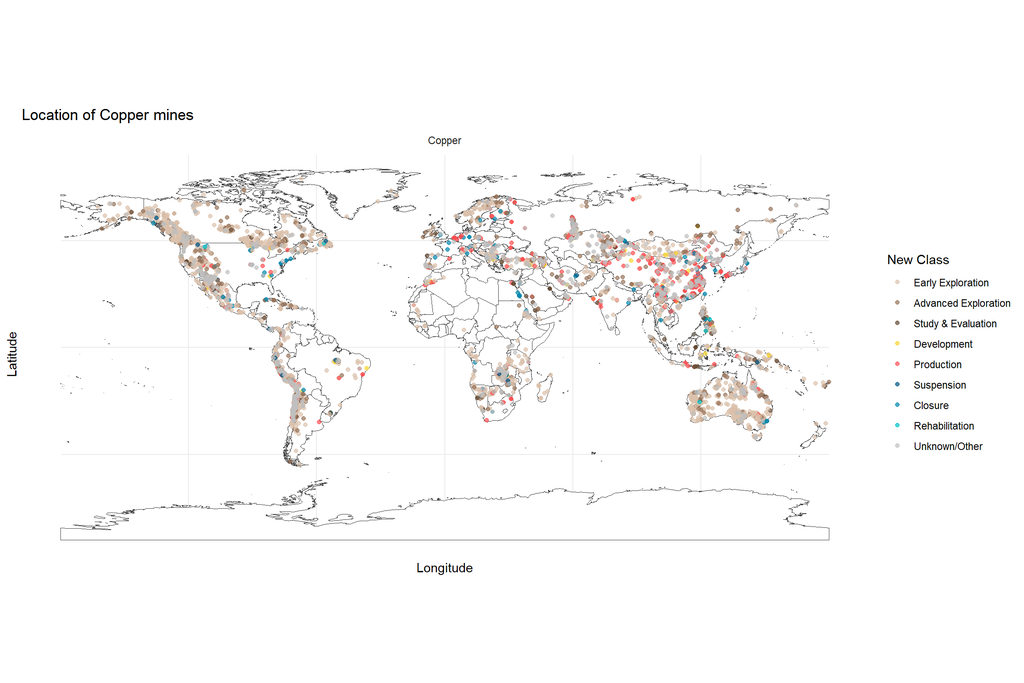

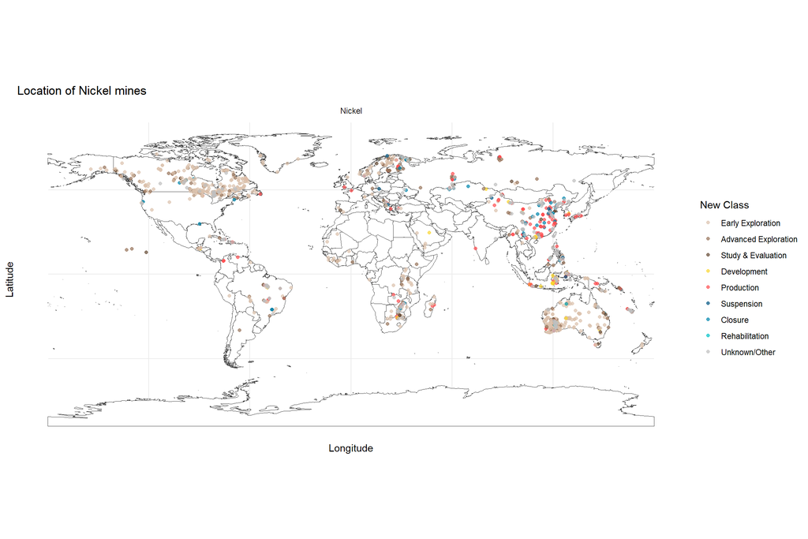

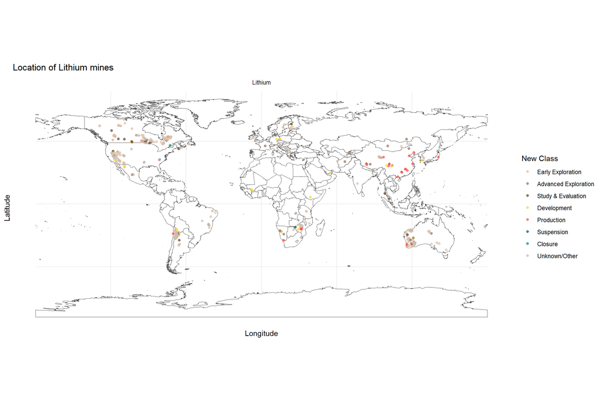

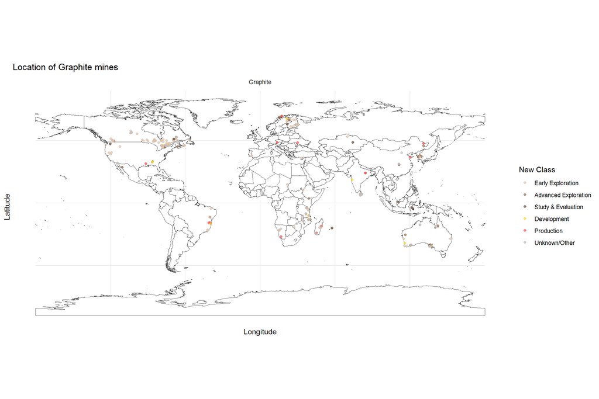

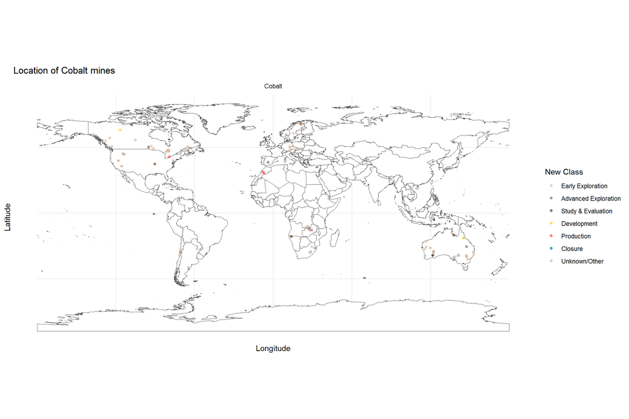

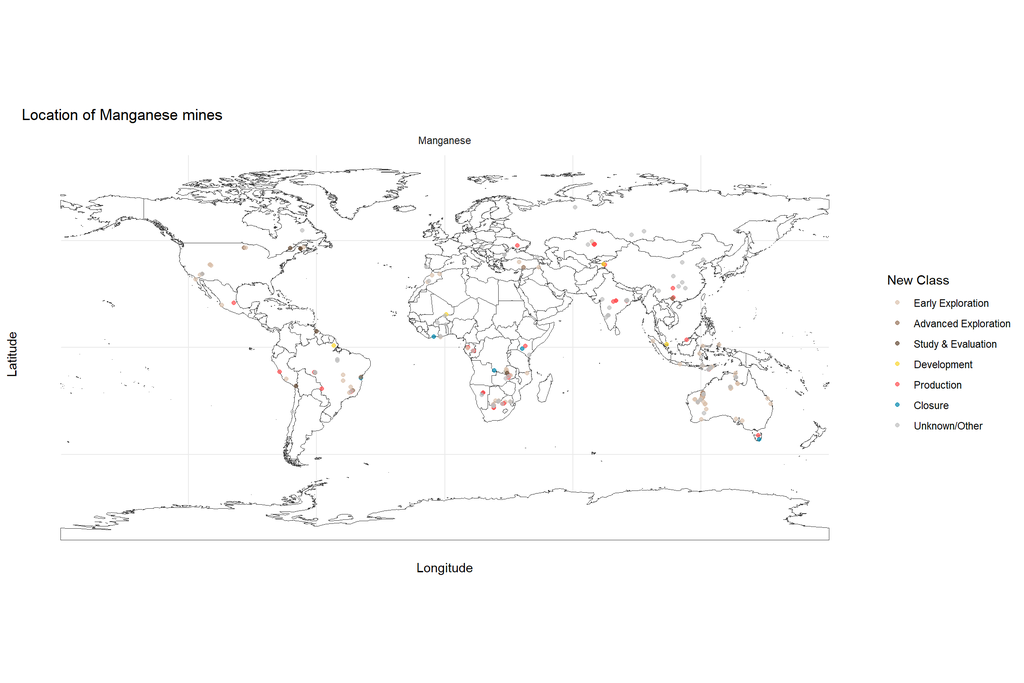